# Reproducible Geospatial Analysis in Python

Apoorva Lal

November 2019

# Introduction

## Geospatial Data in the Social Sciences

- Many topics in the social sciences (Economics, Political Science, Sociology, etc) deal with data generated by units in (usually geographical) space
- Social scientists have paid (relatively) little attention to studying spatial aspects of social scientific problems because of (among other things) computational challenges
- This is beginning to change

## Why use spatial data?

- most objects of interest in empirical social science have (either implicit or explicit) location in space
  - **inferential challenges**
    - SUTVA (Stable Unit Treatment Value Assumption) violations
    - Correlated unobservables (and thus standard errors) (Kelly 2019)
  - **research design opportunities** (Kudamatsu (2018), Donaldson and Storeygard (2016) for overview)
    - spatial merges that allow for richer set of controls (weather, rainfall, topography etc) (Dell, Jones, and Olken 2014)
    - use of administrative boundaries as source of variation (geographical regression discontinuity designs)
      - including digitisation of historical maps (e.g. dozens of papers written based on Murdock atlas digitized by Nunn)
    - use of remote sensing data (e.g. nightlights, LANDSAT, PM2.5)

# The Geospatial analysis toolkit

## Overview

### Proprietary tools

- ArcGIS (~ Excel of GIS)
  - Pros: GUI, good documentation, technical consulting has you covered
  - Cons: GUI, $$$, non-automatable (though python scripting option exists)
  - Windows Only

### Open-Source Tools

- QGIS (~ OpenOffice of GIS)
  - Pros: All of the above + Free
  - Cons: GUI
  - [guide](https://www.osgeo.org/resources/)
- Python / R Spatial Ecosystem
  - Pros: Free, automatable, rapidly developed
  - Cons: Steep(er) Learning Curve, codebases can be moving targets

**Open science should, as far as possible, use FOSS tools**

## Aside on automation

- Empirical social science workflows involve a number of judgement calls in data input/coding, analysis, numerous robustness checks
- This means your data prep/analysis pipeline should be as streamlined as possible to accommodate suggested changes / robustness checks from colleagues, referees, advisors
- Future you will thank you for putting in the extra effort so you don’t have to click through 20 menus in GIS for a robustness check
- However, don’t go overboard; “Premature optimization is the root of all evil” - Don Knuth
  - use notebooks / scripts, but clean namespaces

For a more thorough case for automation and tips to get started, see Gentzkow and Shapiro (2014), Healy (2016)

## This Talk

Overview of GIS Data structures and Geospatial toolkit *in Python* based on my own trial-and-error learning, Arribas-Bel (2019)

Major packages:

- `geopandas` - geospatial analysis tools built on top of widely used `pandas` library
- `rasterio/georasters` - interface with raster data
- `pysal` - spatial econometrics (and much more)
- `rasterstats` - summary statistics of raster datasets for vector features

[underlying C and python libraries - `fiona`, `shapely`, `GDAL`]

## Equivalent tools available in R

See Lovelace, Nowosad, and Muenchow (2019) for overview

## Google Earth Engine - Geocomputation at scale

code.earthengine.google.com

[figure not shown]

# Spatial Data Overview

## Data Structures - vectors

Essentially a dataframe with spatial features attached as an extra (potentially quite complicated) column

- point (lat, long) - spatial column is simple
- polygon (administrative units) - spatial column indexes every vertex
- line (river, road etc) - spatial column indexes every vertex

Typically stored as shapefiles (`.shp + .prj + .shx + dbf`), or `.geojson` files

Start with good habits - [Use GPKG/GeoJSON](http://switchfromshapefile.org/)

## Example - Lines - Land Boundaries between countries

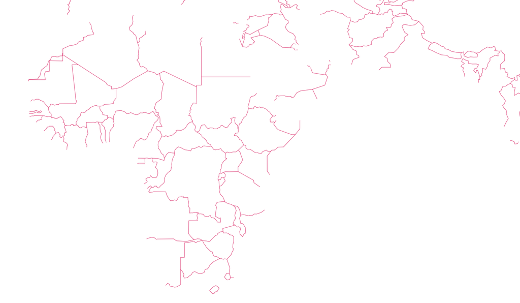

## Data Structures - Rasters

Matrices
$$R := [R_{ij}]$$
of size $m \times n$ holds numerical information (e.g. luminosity)

### Number of bands (layers)

- Single band - only 1 value measured for each cell (e.g. luminosity in nightlights)
- Multiband - multiple values for each cell (e.g. RGB + Infrared in LANDSAT)

typically stored as `.tif` (i.e. it is just an image)

## Example - Hansen Deforestation data

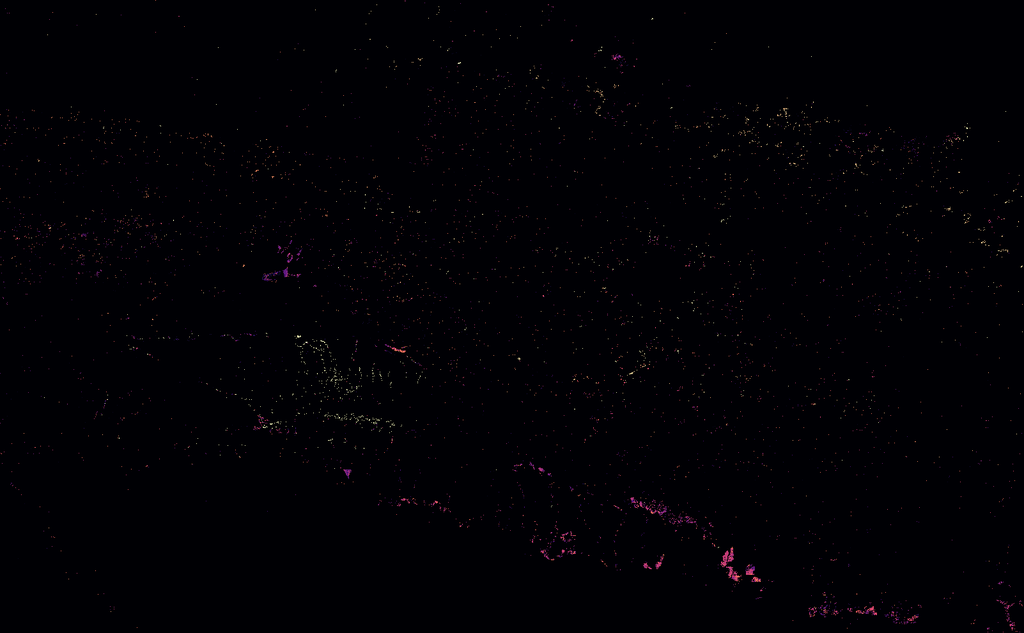

## Example - DMSP Night Lights 2012

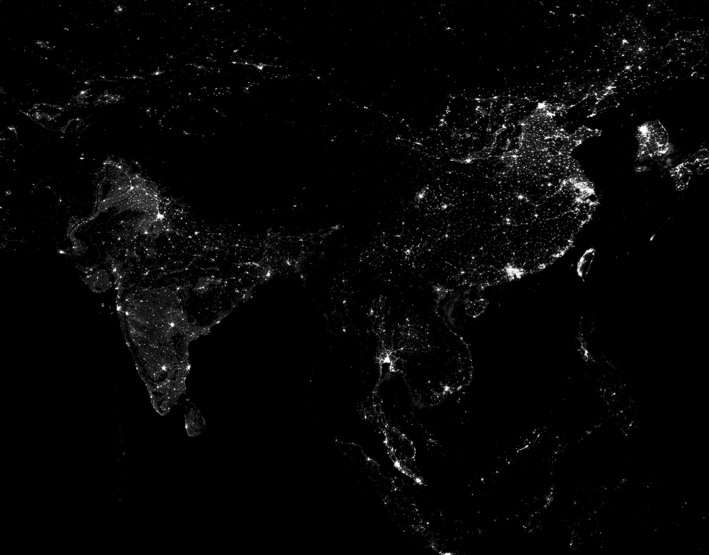

## Misc

- **TIN** - [Three dimensional terrain data](http://desktop.arcgis.com/en/arcmap/10.3/manage-data/tin/fundamentals-of-tin-surfaces.htm)
- **netCDF** - [plaintext array storage](https://pro.arcgis.com/en/pro-app/help/data/multidimensional/what-is-netcdf-data.htm) that is often used instead of rasters [equivalent to raster if you know position of top left coordinate and resolution]

# Geospatial Operations

### Visualisation

- (Choropleth) Maps are great ways to convey spatial information
- Everyone understands them
- Caveat: often sensitive to binning

### Spatial merges / Spatial joins

- subsetting
- polygon-point join (merging cities with countries)
- polygon-polygon join (merging villages with constituencies)

### Distance Computation

- Haversine (great circle) distance between points and line ( e.g. distance to coastline in Nunn (2008))
- Distances from important boundary for regression discontinuity

### Buffers

- Construct region in proximity to point/line
  - Bazzi, Fiszbein, and Gebresilasse (2017) construct frontier from proximity to boundary at which population density dropped below 2 per square mile

# The Python Spatial Ecosystem

## Python Workflow

Use separate `conda` environment for spatial work (or `virtualenv`) - **especially important for spatial libraries because of underlying C dependencies**

- [Docker environment](https://github.com/darribas/gds_env)
- Conda Requirements file - `gds.yml` in repo

Use a modern notebook environment for interactive programming (difficult to do spatial work without seeing what you’re doing)

[figure not shown]

## GeoPandas

Workhorse geospatial library built on top of `pandas` (so it inherits all pandas’ capabilities) with very extensive set of tools for geospatial data management / merging/ plotting

- main data structures
  - `geoseries` (geospatial analogue to Pandas `series`)
  - `GeoDataFrame` (geospatial analogue to Pandas `DataFrame`)
- performs distance, area computations
- Handy set of plot functions built on top of matplotlib, extended by `geoplot`

[Homepage](http://geopandas.org/)

## Georasters / Rasterio / Rasterstats

- [`Georasters`](https://github.com/ozak/georasters) aims to be GeoPandas-like workhorse library for Rasters.
- [`rasterio`](https://rasterio.readthedocs.io/en/stable/quickstart.html) Raster Input and Output - clunkier, but plays nicely with `numpy`
- [`rasterstats`](https://pythonhosted.org/rasterstats/) summarises geospatial rasters based on vector geometries (e.g. calculating mean PM 2.5 levels by province in China)

## PySAL

[Python Spatial Analysis Library](https://pysal.readthedocs.io/en/latest/): Spatial econometrics toolbox. Modular, with libraries for

- `model` - spatial regressions (for an overview of methods, see Ward and Gleditsch (2018))
- `viz` - cluster analysis and visualisation of spatial patterns
- `explore` - Exploratory data analysis, permutation testing, spatial inequality

[Mostly beyond scope of a short talk, but probably most interesting python spatial package]

## To the notebook!

# Other Resources

## Links I found useful

- [Earth Data Science Tutorials](https://www.earthdatascience.org/tags/spatial-data-and-gis/)
- [Automating GIS Processes - University of Helsinki](https://automating-gis-processes.github.io/site/master/index.html)
- [QGIS Documentation](https://docs.qgis.org/3.4/en/docs/)
- [Geospatial Analysis Open Access Book](http://www.spatialanalysisonline.com/HTML/index.html)
- [Historical GIS](http://www.hgis.org.uk/resources.htm)
- [AidData GeoQuery](https://www.aiddata.org/geoquery)

# Thanks!

apoorval@stanford.edu

Arribas-Bel, Dani. 2019. “A Course on Geographic Data Science.” *The Journal of Open Source Education* 2 (14). https://doi.org/https://doi.org/10.21105/jose.00042.

Bazzi, Samuel, Martin Fiszbein, and Mesay Gebresilasse. 2017. “Frontier Culture: The Roots and Persistence of" Rugged Individualism" in the United States.” National Bureau of Economic Research.

Dell, Melissa, Benjamin F Jones, and Benjamin A Olken. 2014. “What Do We Learn from the Weather? The New Climate-Economy Literature.” *Journal of Economic Literature* 52 (3): 740–98.

Donaldson, Dave, and Adam Storeygard. 2016. “The View from Above: Applications of Satellite Data in Economics.” *Journal of Economic Perspectives* 30 (4): 171–98.

Gentzkow, Matthew, and Jesse M Shapiro. 2014. “Code and Data for the Social Sciences: A Practitioner’s Guide.” *Chicago, IL: University of Chicago*.

Kelly, Morgan. 2019. “The Standard Errors of Persistence.” *Working Paper*.

Kudamatsu, Masayuki. 2018. “GIS for Credible Identification Strategies in Economics Research.” *CESifo Economic Studies* 64 (2). Oxford University Press: 327–38.

Lovelace, Robin, Jakub Nowosad, and Jannes Muenchow. 2019. *Geocomputation with R*. CRC Press.

Nunn, Nathan. 2008. “The Long-Term Effects of Africa’s Slave Trades.” *The Quarterly Journal of Economics* 123 (1). MIT Press: 139–76.

Ward, Michael D, and Kristian Skrede Gleditsch. 2018. *Spatial Regression Models*. Vol. 155. Sage Publications.